# Visualization II

# Setup

```r
library(tidyverse)
library(ggstats)
library(ggplot2)
library(jtools)
library(gtsummary)


file<-url("https://github.com/Neilblund/SDSB340-Spring-2026/raw/refs/heads/master/Data/atus.rds")
atus_fmt<-readRDS(file)

label_hours_minutes <- function(x) {
  h <- floor(x / 60)
  m <- round(x %% 60)

  # Logic to create strings like "1h 30m", "45m", or "2h"
  labels <- ifelse(h > 0,
                   paste0(h, "h", ifelse(m > 0, paste0(" ", m, "m"), "")),
                   paste0(m, "m"))

  # Ensure NAs remain NAs
  labels[is.na(x)] <- NA
  return(labels)
}
```

### Long data

- ggplot works best with long format data. If we want to visualize several variables at once, you’ll often need to do some additional data wrangling.

### Long data

```r
# store the variable labels in a list
labels<-lapply(atus_fmt, function(x) attr(x, "label"))|>
  unlist()
# make long format data
time_long<-atus_fmt|>
  # selecting only the weight + columns related to activities
  select(sleep:travel, TUFINLWGT)|>
  # pivoting everything except the weights
  pivot_longer(cols=-TUFINLWGT)|>
  # adding the labels as a new column
  mutate(label = labels[name])

# viewing the results
time_long|>
  slice_head(n=10)
```

```
# A tibble: 10 × 4
   TUFINLWGT name          value label
       <dbl> <chr>         <dbl> <chr>
 1 18318135. sleep           540 Sleep
 2 18318135. self_care         0 Personal care
 3 18318135. chores           30 Household chores
 4 18318135. hh_caretaking   203 Caring for household members
 5 18318135. nonhh_care        0 Caring for non-hh members
 6 18318135. work            492 Work & work Related activities.
 7 18318135. education         0 Education
 8 18318135. shopping          0 Consumer purchases
 9 18318135. care_services     0 Professional & Personal Care Services
10 18318135. hh_services       0 Household services
```

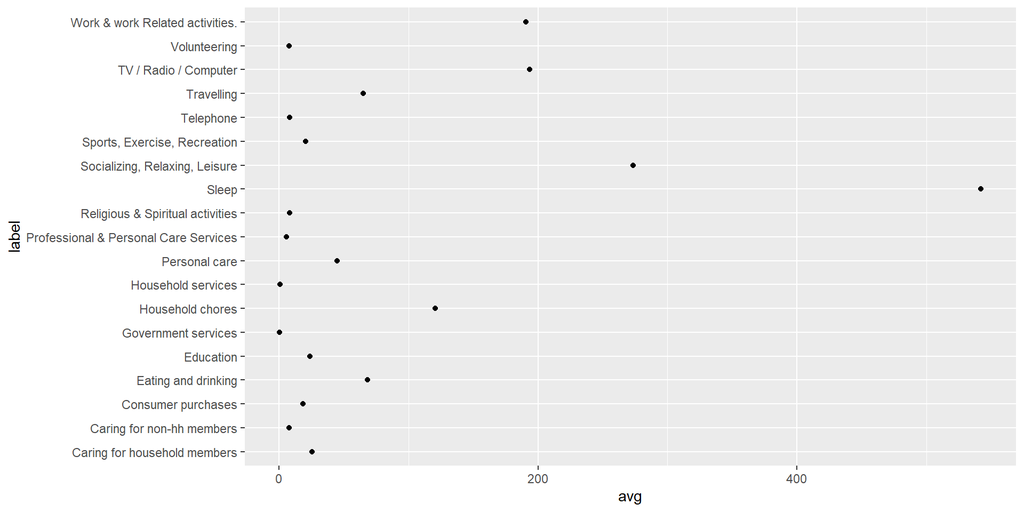

```r
time_aggregate<-time_long|>
  group_by(label)|>
  summarize(avg = weighted.mean(value, w=TUFINLWGT))
ggplot(time_aggregate, aes(x = avg, y=label)) + geom_point()
```

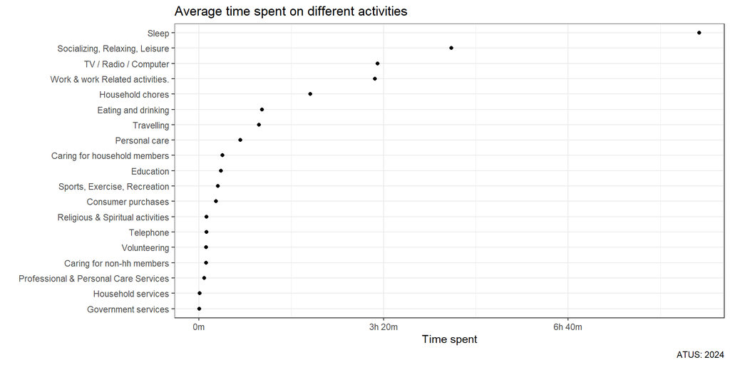

```r
time_aggregate<-time_long|>
  group_by(label)|>
  summarize(avg = weighted.mean(value, w=TUFINLWGT))|>
  mutate(label = reorder(label, avg))

ggplot(time_aggregate, aes(x = avg, y=label)) +
  geom_point() +
  labs(
 title = "Average time spent on different activities",
    x = "Time spent",
    y = "",
    caption = "ATUS: 2024"  ) +
  scale_x_continuous(labels = label_hours_minutes) +
  theme_bw()
```

### Faceting and scaling

Big differences in the scaling can make it difficult to identify *relative* changes within each group. Faceting with “free” axes can be a useful way to highlight a change at the expense of distorting absolute values.

### Faceting and scaling

This plot shows hours spent on different activities by age using the same scale for each facet.

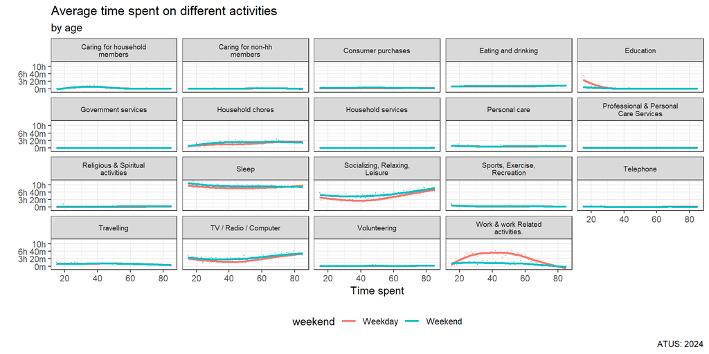

```r
time_long<-atus_fmt|>
  mutate(weekend = factor(TUDIARYDAY %in% c("Saturday", "Sunday"),
                          levels = c(FALSE, TRUE),
                          labels=c("Weekday", "Weekend")
                          ))|>
  select(sleep:travel, TEAGE, TUFINLWGT, weekend)|>
  pivot_longer(cols=-c(TUFINLWGT, weekend, TEAGE))|>
  mutate(label = labels[name])

time_aggregate<-time_long|>
  group_by(label, weekend, TEAGE)|>
  summarize(avg = weighted.mean(value, w=TUFINLWGT))


ggplot(time_aggregate, aes(x = TEAGE, y =avg,
                           color=weekend,
                           group=weekend)) +
  geom_point(size=.1) +
  geom_smooth(se=FALSE) +
  labs(
    title = "Average time spent on different activities",
    subtitle = "by age",
    x = "Time spent",
    y = "",
    caption = "ATUS: 2024"  ) +
  scale_y_continuous(labels = label_hours_minutes) +
  theme_bw() +
  facet_wrap(~label,   labeller = label_wrap_gen(width = 25)) +
  theme(legend.position = "bottom",
        strip.text = element_text(size = 7)
        )
```

Here’s what it looks like using a “free” y scale:

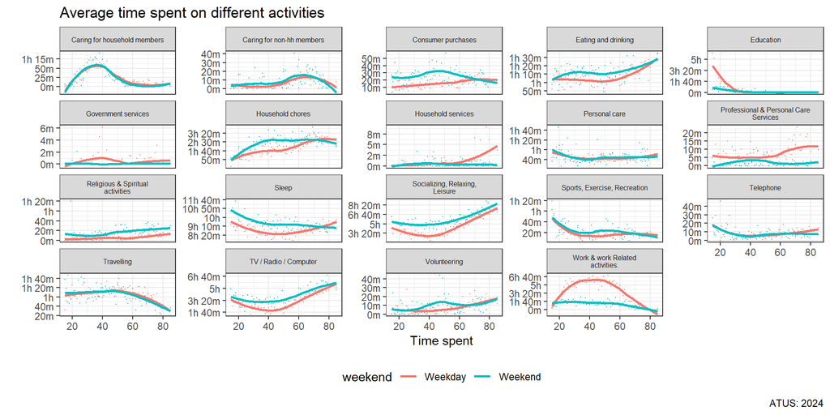

```r
time_long<-atus_fmt|>
  mutate(weekend = factor(TUDIARYDAY %in% c("Saturday", "Sunday"),
                          levels = c(FALSE, TRUE),
                          labels=c("Weekday", "Weekend")
                          ))|>
  select(sleep:travel, TEAGE, TUFINLWGT, weekend)|>
  pivot_longer(cols=-c(TUFINLWGT, weekend, TEAGE))|>
  mutate(label = labels[name])

time_aggregate<-time_long|>
  group_by(label, weekend, TEAGE)|>
  summarize(avg = weighted.mean(value, w=TUFINLWGT))


ggplot(time_aggregate, aes(x = TEAGE, y =avg,
                           color=weekend,
                           group=weekend)) +
  geom_point(size=.1) +
  geom_smooth(se=FALSE) +
  labs(
    title = "Average time spent on different activities",
    x = "Time spent",
    y = "",
    caption = "ATUS: 2024"  ) +
  scale_y_continuous(labels = label_hours_minutes) +
  theme_bw() +
  facet_wrap(~label,
             # Free scale on the y-axis
             scales='free_y',
             labeller = label_wrap_gen(width = 30)
             ) +
  theme(legend.position = "bottom",
        strip.text = element_text(size = 6)
        )
```

## Try it out

- Variables beginning with `t130` are specific sports and recreation activities. Select all of these variables and put your results in long format (`t130101:t130301`)
- Get a break down of time spent in different activities by weekly income (`TRERNWA`)

## Survey data

Some special considerations for visualizing survey data

- Visualizations for categorical data
- Visualizing weighted responses
- Handling over-plotting
- Visualizing the margin of error
- Visualizing the results from a model

### Survey data: Categorical Responses and Weights

- Many survey variables are categorical rather than continuous, which can restrict our options for visualization.

#### Survey data: Bar plots

`geom_bar` automatically creates bars proportional to the number of observations.

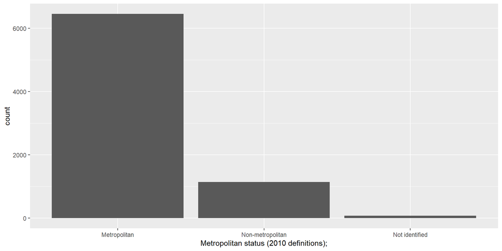

```r
ggplot(atus_fmt, aes(x=GTMETSTA)) +
  geom_bar()
```

`geom_col` creates bars that are proportional to a value in the data (so you need to create the aggregated data yourself)

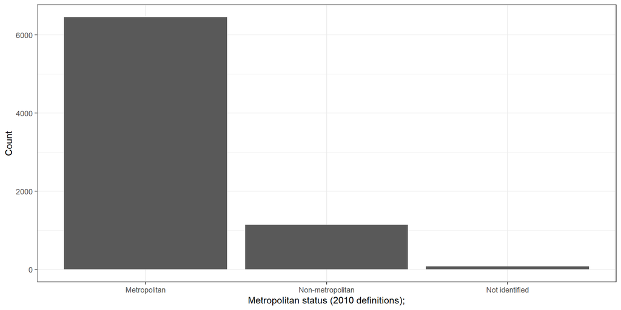

```r
atus_agg<-atus_fmt|>
  group_by(GTMETSTA)|>
  summarise(Count = n())

ggplot(atus_agg, aes(x=GTMETSTA, y= Count)) +
  geom_col() +
  theme_bw()
```

Doing the aggregation separately offers better flexibility for calculations and formatting.

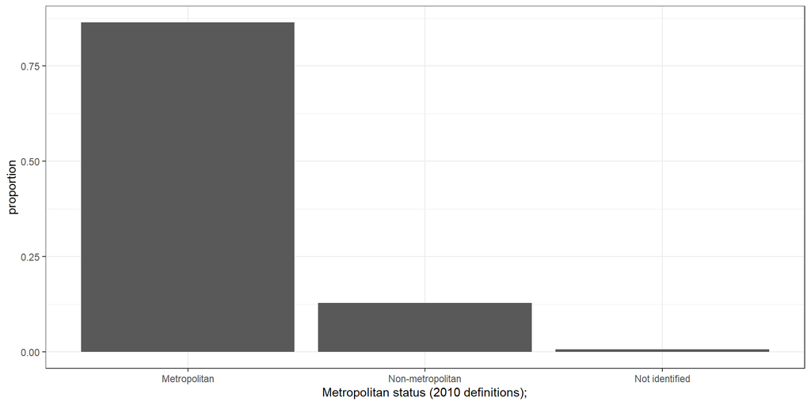

```r
atus_agg<-atus_fmt|>
  group_by(GTMETSTA)|>
  summarise(count = sum(TUFINLWGT))|>
  mutate(proportion = count /sum(count))

ggplot(atus_agg, aes(x=GTMETSTA, y=proportion)) +
  geom_col() +
  theme_bw()
```

Creating a dumbbell plot using `geom_pointrange` can be an appealing alternative to bar plots that focuses more attention on the important stuff (the ends)

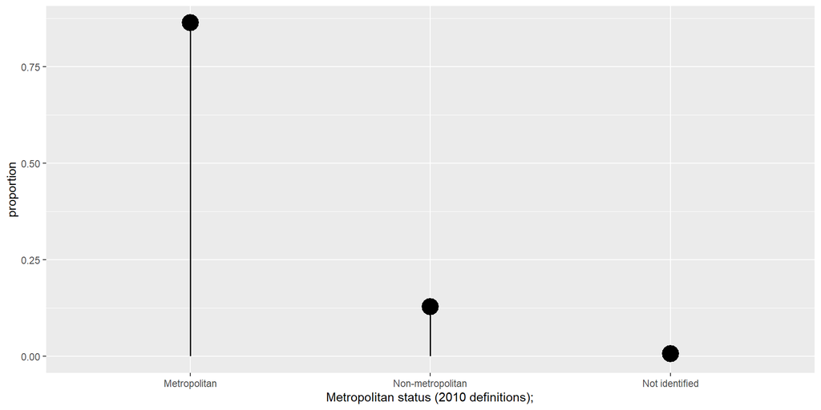

```r
atus_agg<-atus_fmt|>
  group_by(GTMETSTA)|>
  summarise(count = sum(TUFINLWGT))|>
  mutate(proportion = count /sum(count))

ggplot(atus_agg, aes(x=GTMETSTA, y=proportion)) +
    geom_pointrange(aes(ymin = 0, ymax = proportion),
                  # making wider lines
                  lwd=.7,
                  # increasing the point size
                  size = 1.5)
```

#### Survey data: Two-way bar plots

```r
atus_agg<-atus_fmt|>
  group_by(telework, PEEDUCA)|>
  summarise(count = sum(TUFINLWGT))|>
  ungroup()|>
  drop_na()|>
  group_by(PEEDUCA)|>
  mutate(proportion = count /sum(count))

atus_agg
```

```
# A tibble: 28 × 4
   telework PEEDUCA                                             count proportion
   <fct>    <fct>                                               <dbl>      <dbl>
 1 Yes      9th grade                                          9.72e6    0.0198
 2 Yes      10th grade                                         4.87e6    0.00783
 3 Yes      11th grade                                         4.79e7    0.0443
 4 Yes      12th grade - no diploma                            1.08e7    0.0177
 5 Yes      High school graduate - diploma or equivalent (GED) 1.25e9    0.0794
 6 Yes      Some college but no degree                         1.18e9    0.156
 7 Yes      Associate degree - occupational/vocational         2.72e8    0.121
 8 Yes      Associate degree - academic program                6.08e8    0.186
 9 Yes      Bachelor's degree (BA, AB, BS, etc.)               6.40e9    0.397
10 Yes      Master's degree (MA, MS, MEng, MEd, MSW, etc.)     3.57e9    0.460
# ℹ 18 more rows
```

In this instance, the axis labels are too long to fit on the page.

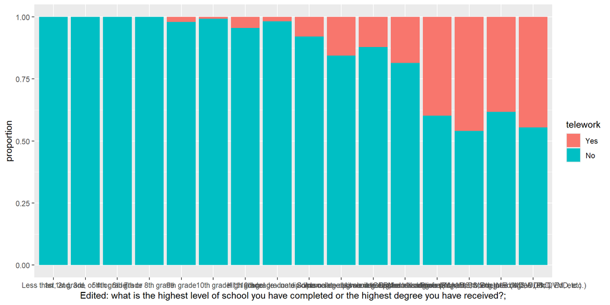

```r
ggplot(atus_agg, aes(x=PEEDUCA,
                     y=proportion,
                     fill=telework)) +
  geom_col()
```

Using `coord_flip` (or just reversing what goes on the x and y axis) is often an easy fix in this situation.

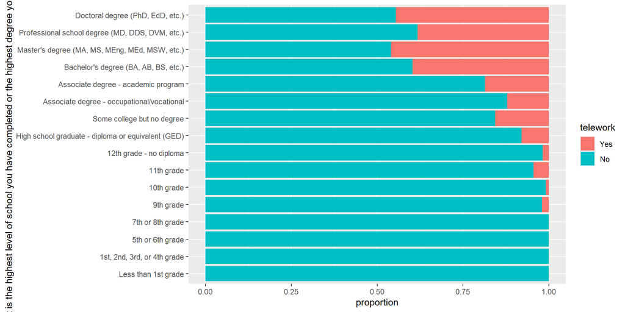

```r
ggplot(atus_agg, aes(x=PEEDUCA,
                     y=proportion,
                     fill=telework)) +
  geom_col() +
  coord_flip()
```

Adding `position='dodge'` to the plot will give side-by-side columns, instead of stacked bars.

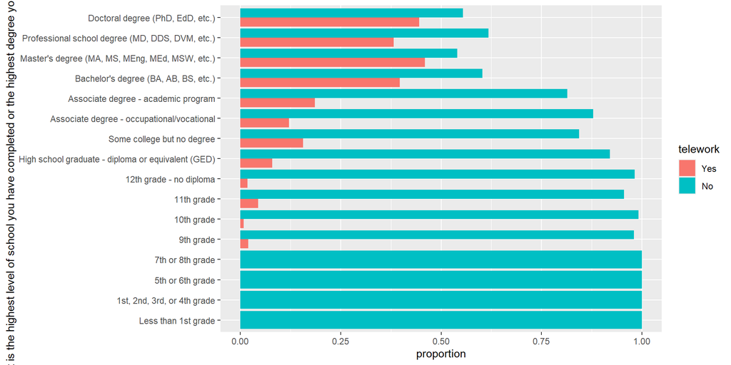

```r
ggplot(atus_agg, aes(x=PEEDUCA,
                     y=proportion,
                     fill=telework)) +
  coord_flip()+
  geom_col(position='dodge')
```

`scales::label_percent()` will automatically turn proportions into formatted % tick marks:

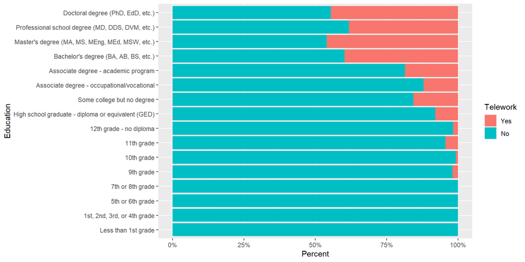

```r
ggplot(atus_agg, aes(x=PEEDUCA,
                     y=proportion,
                     fill=telework)) +
  geom_col() +
  coord_flip()+
  scale_y_continuous(labels = scales::label_percent())+
  labs(x = "Education",
       y = "Percent",
       fill  = "Telework"
       )
```

You can also simplify the calculation of weighted proportions here using the `srvyr` package.

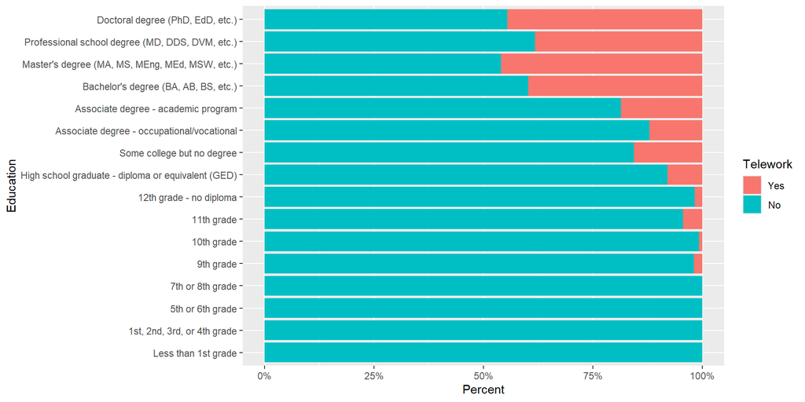

```r
library(srvyr)
atus_svy<-atus_fmt|>
  as_survey_design(weights = TUFINLWGT)

# getting survey proportions
atus_agg<-atus_svy|>
  # drop missing values
  drop_na(telework, PEEDUCA)|>
  # get proportions summing to 100% by education
  group_by(PEEDUCA, telework)|>
  summarise(survey_prop(vartype = 'ci'))

ggplot(atus_agg, aes(x=PEEDUCA,
                     y=coef,
                     fill=telework)) +
  geom_col() +
  coord_flip()+
  scale_y_continuous(labels = scales::label_percent())+
  labs(x = "Education",
       y = "Percent",
       fill  = "Telework"
       )
```

#### Survey data: Plotting a likert-type question

Plotting Likert items can present some unique challenges. We’ll walk through a couple examples for how you might create visuals for a series of agree/disagree questions.

#### Survey data: Likert Plots

Here’s an example of a Likert scale plot using regular ggplot functions.

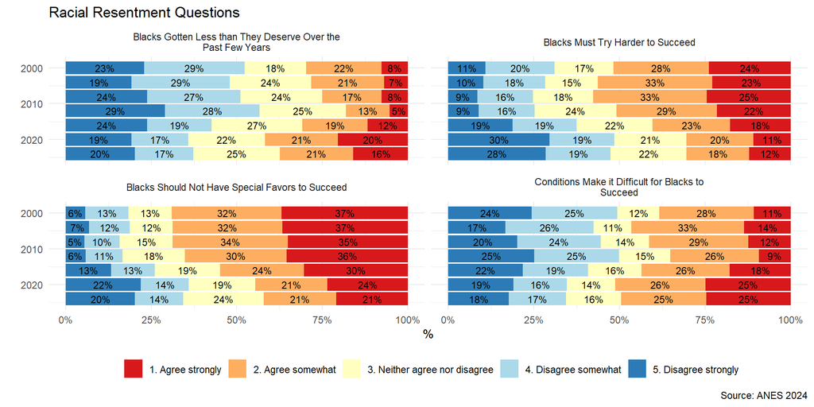

```r
site<-'https://github.com/Neilblund/SDSB340-Spring-2026/raw/refs/heads/master/Data/anes_tssubset.rds'
anes_subset<-readRDS(url(site))

labels<-sapply(anes_subset, function(x) attr(x, 'label'))

anes_long<-anes_subset|>
  select(id, full.weight, year, c(rr_1, rr_2, rr_3, rr_4))|>
  pivot_longer(cols = c(rr_1, rr_2, rr_3, rr_4))

anes_long$qlabel<-unlist(labels[anes_long$name])



# aggregating by year and question
summary_data<-anes_long|>
  drop_na()|>
  group_by(qlabel, value, year)|>
  summarise(n = sum(full.weight))|>
  ungroup()|>
  group_by(qlabel, year)|>
  mutate(proportion = n/sum(n),
         label = sprintf("%.0f%%",
                         proportion*100)
         )

# plotting by year and faceting by question
ggplot(summary_data, aes(x=year, y=proportion, fill=value, label=label)) +
  geom_col() +
  geom_text(position = position_stack(vjust = 0.5), size=3)+
  scale_y_continuous(labels = scales::percent) +
  scale_x_reverse()+
  theme_minimal() +
  coord_flip() +
  scale_fill_discrete(palette = "RdYlBu")  +
  labs(x = "",
       y= "%",
       fill = "",
       title = 'Racial Resentment Questions',
       caption = 'Source: ANES 2024'
  )  +
    theme(legend.position = "bottom") +
  facet_wrap(~qlabel,  labeller = label_wrap_gen(width = 50))
```

#### Survey data: Likert Plots

The `gglikert` function from the `ggstats` package can produce detailed visualizations for likert type questions with minimal code.

Note that the output produced by the `gglikert` function is still a ggplot object, so you can still add layers just like you would with other plots.

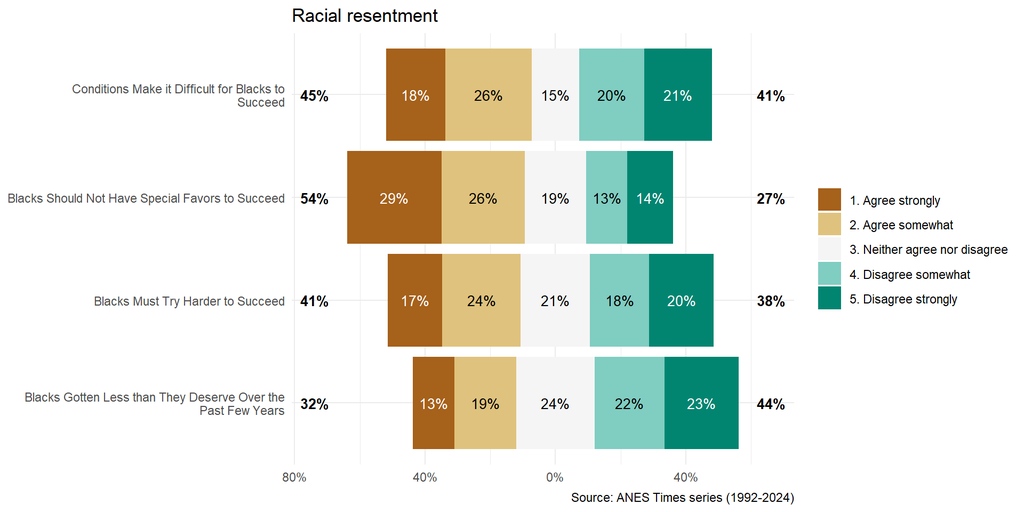

#### Survey data: Likert Plots

You don’t need to pivot the data into long format for this to work, just select multiple columns in the “include” argument.

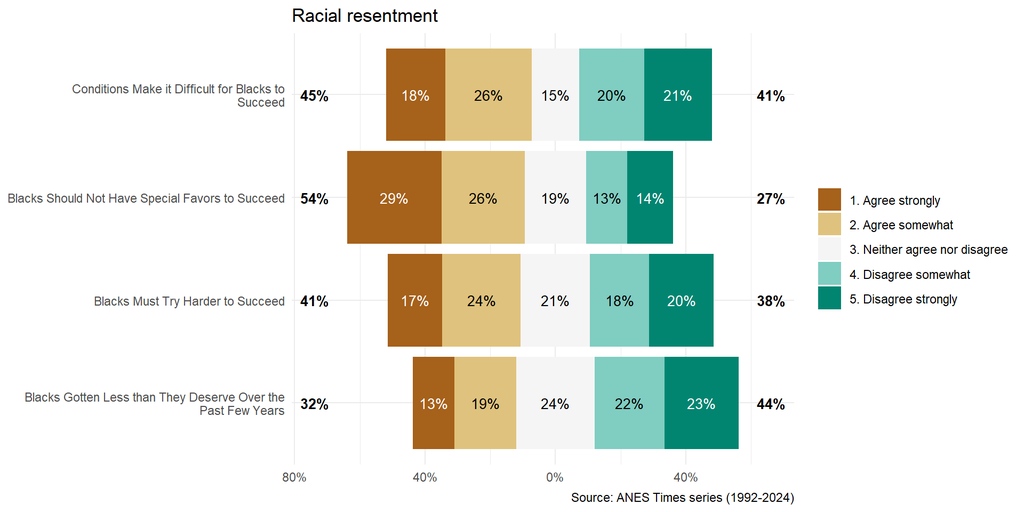

```r
anes_subset|>
  gglikert(
    include = c(rr_1, rr_2, rr_3, rr_4),
    weights = full.weight,
  ) +
  theme_minimal() +
  labs(title = "Racial resentment",
       caption = "Source: ANES Times series (1992-2024)"
       )
```

#### Survey data: Likert Plots

The `facet_rows` and `facet_cols` arguments will produce faceted output:

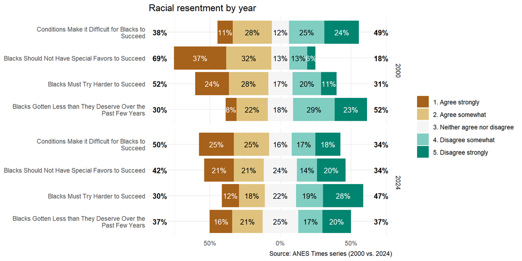

```r
anes_subset|>
  filter(year %in%c(2000, 2024))|>
  gglikert(
    include = c(rr_1, rr_2, rr_3, rr_4),
    weights = full.weight,
    facet_rows = vars(year)
  ) +
  theme_minimal() +
  labs(title = "Racial resentment by year",
       caption = "Source: ANES Times series (2000 vs. 2024)"

       )
```

#### Survey data: Likert Plots

If the goal is to show change over time, it might make sense to draw plots separately for each question so that the results for each year are easier to compare.

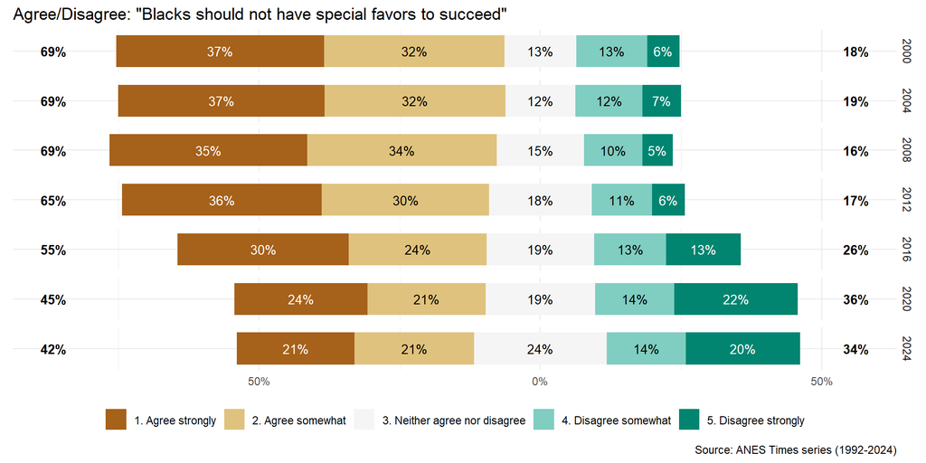

```r
# alternatively: looking at a single question over a longer period of time

anes_subset|>
  gglikert(
    include = rr_2,
    facet_rows = vars(year),
    weights = full.weight,
    variable_labels=c(rr_2 = "")
  ) +
  theme_minimal() +
  theme(legend.position = "bottom") +
  labs(title = "Agree/Disagree: \"Blacks should not have special favors to succeed\"" ,
       caption = "Source: ANES Times series (1992-2024)"

  )
```

### Overplotting

### Handling overplotting

Over-plotting occurs when data points or labels overlap. This happens a lot with survey variables that only have a few discrete values.

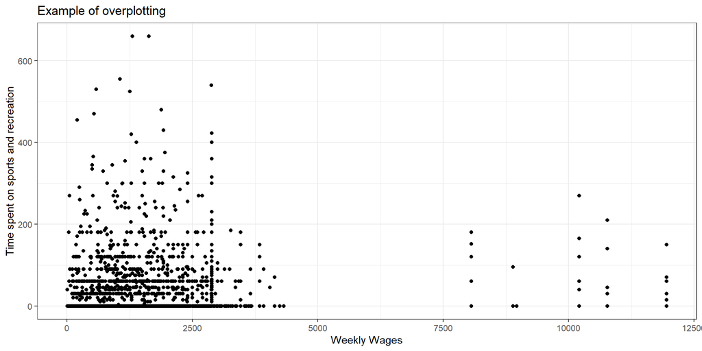

```r
ggplot(atus_fmt, aes(x=TRERNWA/100, y=sports_recreation )) +
  geom_point() +
  theme_bw() +
  labs(title = "Example of overplotting",
       x = "Weekly Wages",
       y="Time spent on sports and recreation"
  )
```

#### Handling overplotting

Some options

Using a different shape or size (ex: `pch=21` will give hollow circles)

Changing the transparency level (adjusting `alpha` to a value less than 1 will make transparent points)

Adding random noise with a “jitter” (take note of whether you need more noise on the X or Y axis)

Hexbin plots “bin” the data into groups and then use color-coding to indicate the number of observations in each bin (like a histogram in 2-dimensions)

2D density plots are analogous to a kernel density plot.

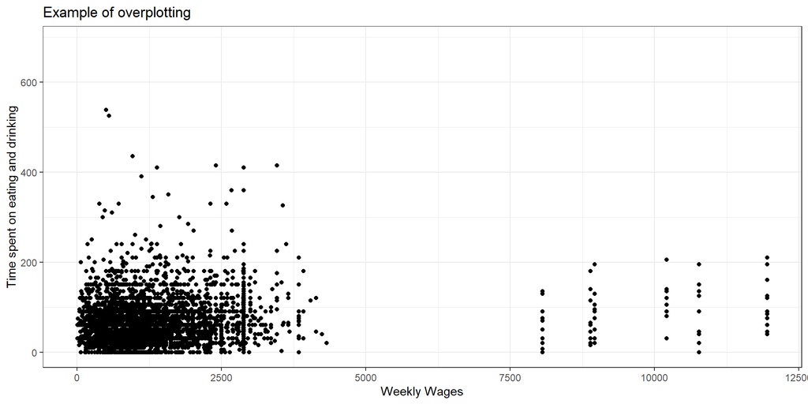

```r
ggplot(atus_fmt, aes(x=TRERNWA/100, y=food )) +
  geom_point() +
  theme_bw() +
  labs(title = "Example of overplotting",
       x = "Weekly Wages",
       y="Time spent on eating and drinking"
  )
```

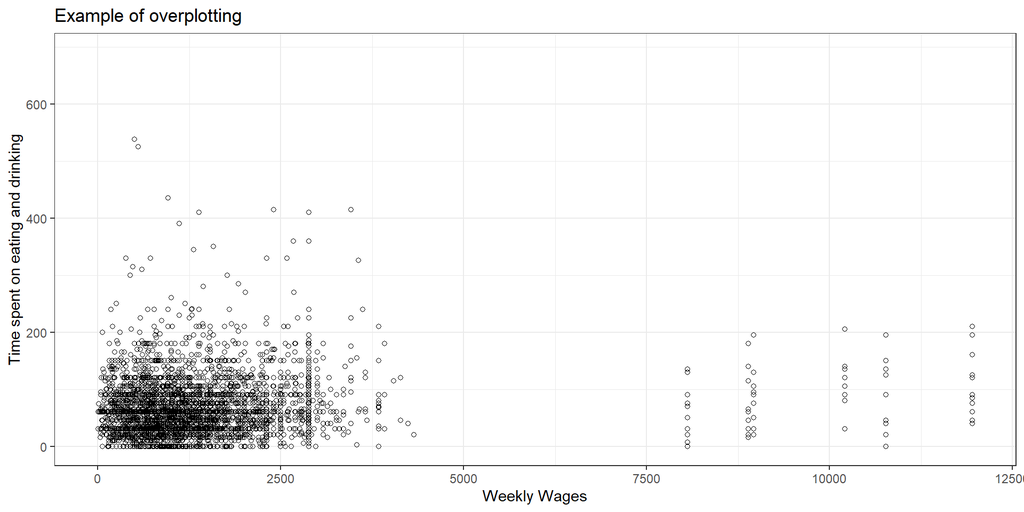

```r
ggplot(atus_fmt, aes(x=TRERNWA/100, y=food )) +
  geom_point(pch=21) +
  theme_bw() +
  labs(title = "Example of overplotting",
       x = "Weekly Wages",
       y="Time spent on eating and drinking"
  )
```

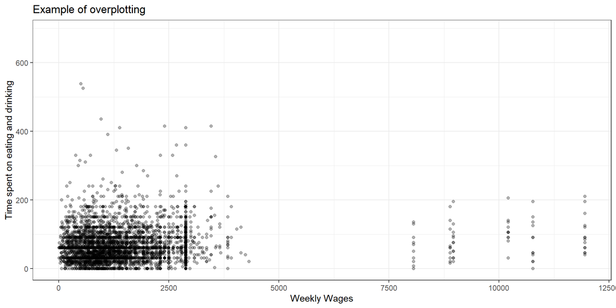

```r
ggplot(atus_fmt, aes(x=TRERNWA/100, y=food )) +
  geom_point(alpha=.3) +
  theme_bw() +
  labs(title = "Example of overplotting",
       x = "Weekly Wages",
       y="Time spent on eating and drinking"
  )
```

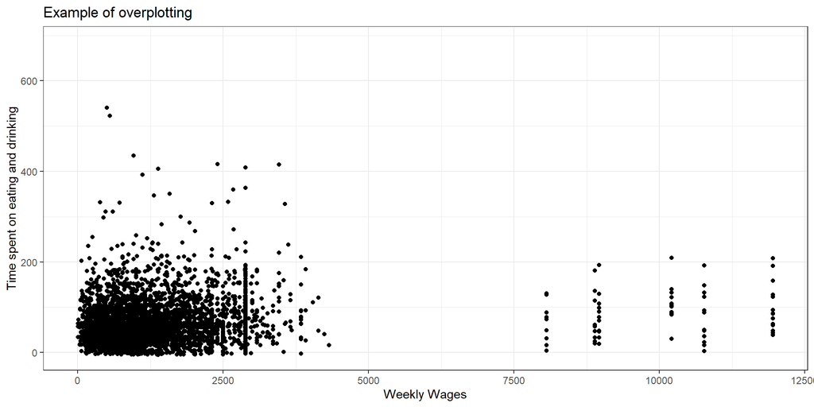

```r
ggplot(atus_fmt, aes(x=TRERNWA/100, y=food )) +
  geom_point(position = position_jitter(height=5, width=0)) +
  theme_bw() +
  labs(title = "Example of overplotting",
       x = "Weekly Wages",
       y="Time spent on eating and drinking"
  )
```

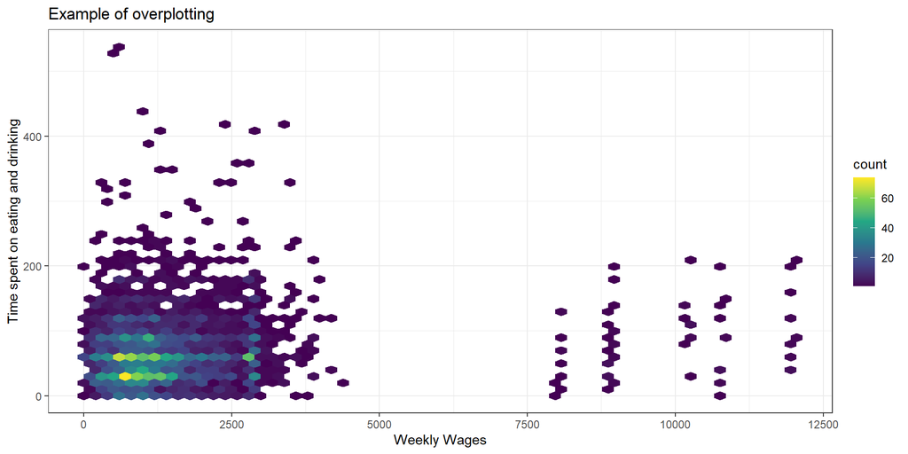

```r
ggplot(atus_fmt, aes(x=TRERNWA/100, y=food )) +
  geom_hex(bins=60) +
  theme_bw() +
  labs(title = "Example of overplotting",
       x = "Weekly Wages",
       y="Time spent on eating and drinking"
  ) +
  scale_fill_viridis_c()
```

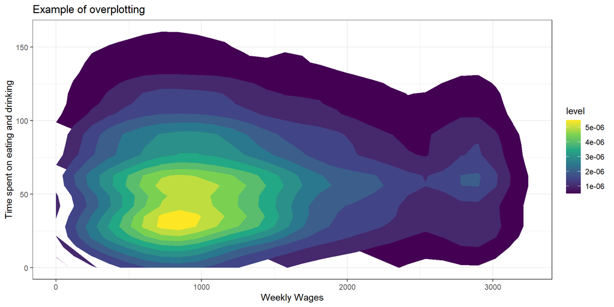

```r
ggplot(atus_fmt, aes(x=TRERNWA/100, y=food)) +
  stat_density_2d(aes(fill = ..level..), geom = "polygon") +
  theme_bw() +
  labs(title = "Example of overplotting",
       x = "Weekly Wages",
       y="Time spent on eating and drinking"
  ) +
  scale_fill_viridis_c()
```

#### Handling overplotting

When all else fails, you might consider making one of the variables discrete and then use a box plot or strip chart to visualize the relationship of interest.

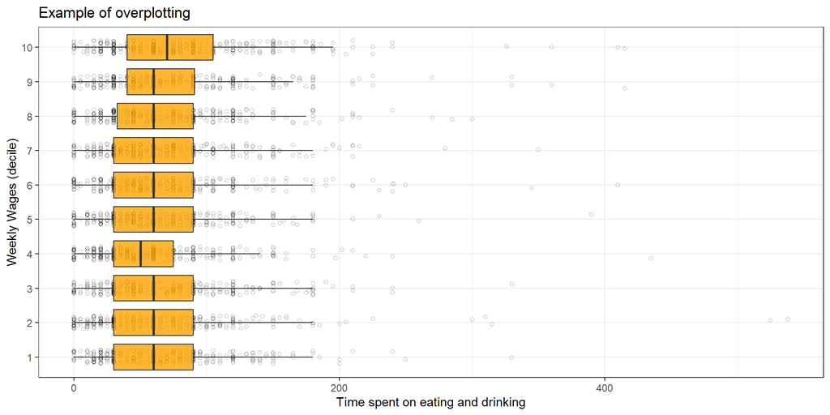

```r
atus_fmt|>
  mutate(income_discrete = factor(ntile(TRERNWA/100, 10))
         )|>
  drop_na(income_discrete)|>
ggplot(aes(x=income_discrete, y=food)) +
  geom_point(position = position_jitter(width=.2, height=0), alpha=.3, pch = 21) +
  geom_boxplot(outliers=FALSE, alpha=.8, fill='orange') +
  theme_bw() +
  labs(title = "Example of overplotting",
       x = "Weekly Wages (decile)",
       y="Time spent on eating and drinking"
  ) +
  coord_flip()
```

#### Handling overplotting

### Visualizing Uncertainty and Model Results

How should we visualize an estimate with uncertainty?

```r
yngchild<-atus_fmt|>
  filter(TRYHHCHILD < 5)|>
  droplevels()

yngchild |>
  tbl_summary(
    include = hh_caretaking,
    by = TESEX,
    statistic = all_continuous() ~ "{mean} ({sd})"
  ) |>
  add_ci()
```

| **Characteristic** | **Male** N = 323<sup>1</sup> | **95% CI** | **Female** N = 402<sup>1</sup> | **95% CI** |
| --- | --- | --- | --- | --- |
| Caring for household members | 119 (143) | 104, 135 | 176 (152) | 162, 191 |

<sup>1</sup> Mean (SD)  
Abbreviation: CI = Confidence Interval

#### Visualizing Uncertainty

`stat_summary` functions can be used to compute both a mean and a confidence interval for the same value:

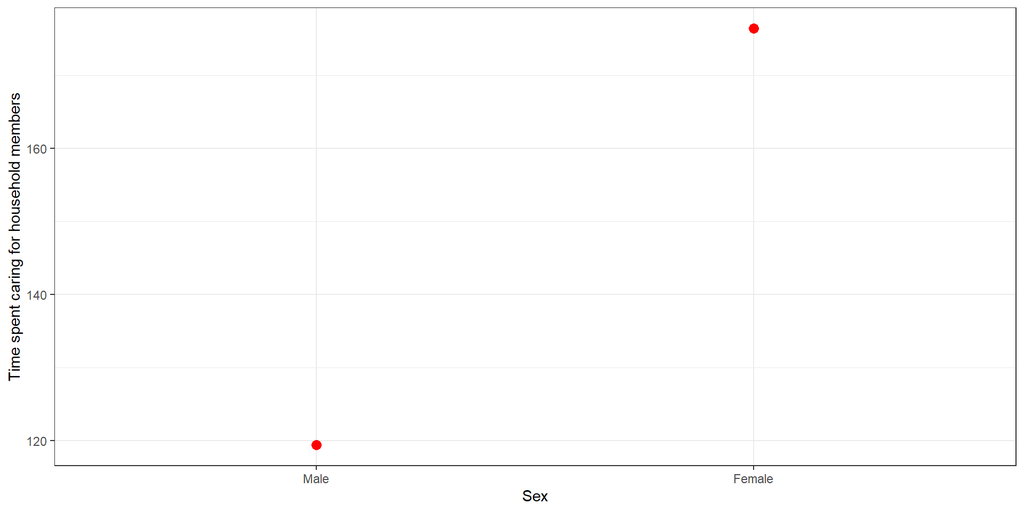

```r
ggplot(yngchild, aes(x = TESEX, y = hh_caretaking)) +
  stat_summary(fun = mean,
               geom = "point",
               size = 3,
               color = "red") +
  theme_bw() +
  labs(x= "Sex",
       y="Time spent caring for household members")
```

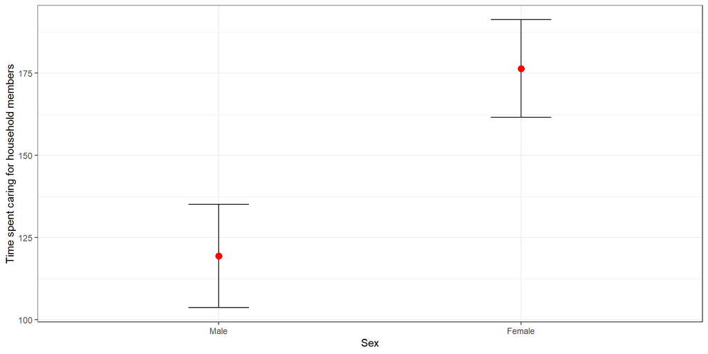

```r
ggplot(yngchild, aes(x = TESEX, y = hh_caretaking)) +
  stat_summary(fun.data = mean_cl_normal,
               geom = "errorbar",
               width = 0.2) +
  stat_summary(
    fun = mean,
    geom = "point",
    size = 3,
    color = "red"
  ) +
  theme_bw() +
  labs(x = "Sex",
       y = "Time spent caring for household members")
```

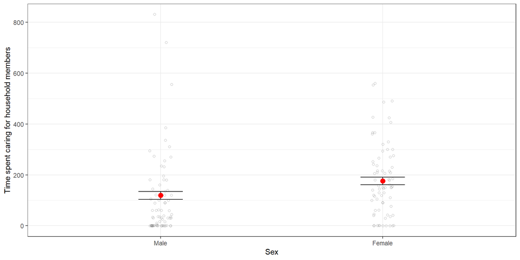

```r
ggplot(yngchild, aes(x = TESEX, y = hh_caretaking)) +
  geom_jitter(
    data = ~ sample_frac(.x, 0.20),
    alpha = .3,
    width = .05,
    height = 1,
    pch = 21
  ) +
  stat_summary(fun.data = mean_cl_normal,
               geom = "errorbar",
               width = 0.2) +
  stat_summary(
    fun = mean,
    geom = "point",
    size = 3,
    color = "red"
  ) +
  theme_bw() +
  labs(x = "Sex", y = "Time spent caring for household members")
```

#### Visualizing Uncertainty

Keep in mind that sample size impacts the width of your confidence intervals. So you might prefer to combine similar groups to improve statistical power.

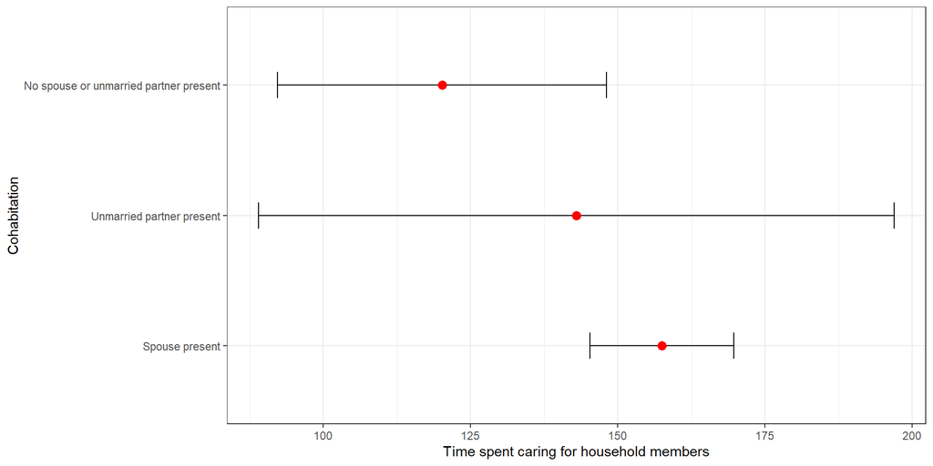

```r
yngchild |>
  ggplot(aes(x = TRSPPRES, y = hh_caretaking)) +
  stat_summary(fun.data = mean_cl_normal,
               geom = "errorbar",
               width = 0.2) +
  stat_summary(
    fun = mean,
    geom = "point",
    size = 3,
    color = "red"
  ) +
  theme_bw() +
  labs(x = "Cohabitation",
       y = "Time spent caring for household members") +
  coord_flip()
```

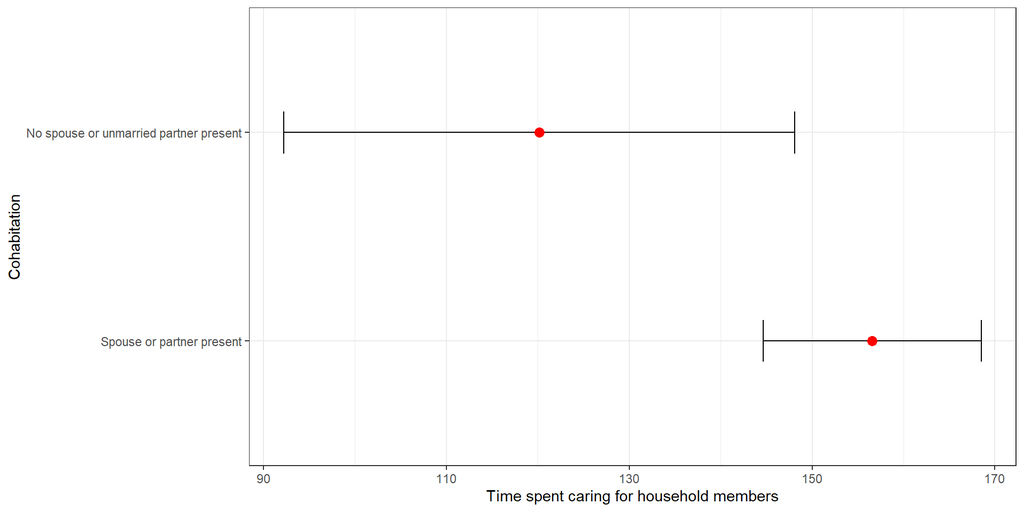

```r
yngchild$cohab<-fct_collapse(
  yngchild$TRSPPRES,
  `Spouse or partner present` = c("Unmarried partner present", "Spouse present"))

yngchild |>
  ggplot(aes(x = cohab, y = hh_caretaking)) +
  stat_summary(fun.data = mean_cl_normal,
               geom = "errorbar",
               width = 0.2,) +
  stat_summary(
    fun = mean,
    geom = "point",
    size = 3,
    color = 'red'
  ) +
  theme_bw() +
  labs(x = "Cohabitation",
       y = "Time spent caring for household members") +

  coord_flip()
```

#### Visualizing Model Results: Regression

- Regression models give the effect of a one unit increase in one or more independent variables on the expected value of some outcome variable.
- They’re a useful way to show the association between two variables while controlling for some third (or fourth or fifth additional characteristic)

#### Visualizing Model Results: Regression

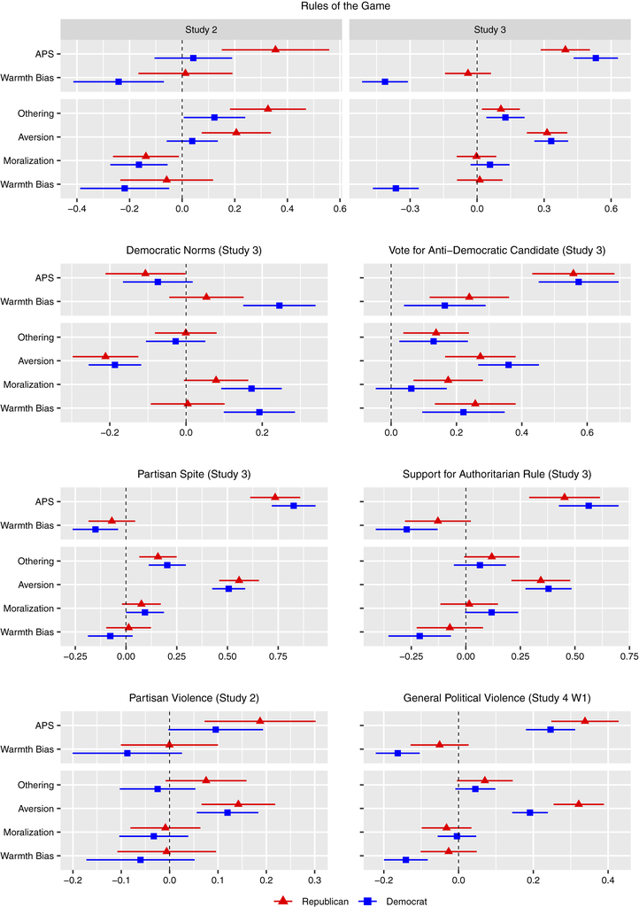

from: Campos N, Federico C. A New Measure of Affective Polarization. American Political Science Review. 2026;120(1):160-178. doi:10.1017/S0003055425000255

#### Visualizing Model Results: Regression

```r
model<-lm(hh_caretaking ~ TESEX + cohab + TRYHHCHILD , data=yngchild )
# getting formatted regression output:
tbl_regression(model)
```

| **Characteristic** | **Beta** | **95% CI** | **p-value** |
| --- | --- | --- | --- |
| TESEX |  |  |  |
| Male | — | — |  |
| Female | 63 | 41, 84 | <0.001 |
| cohab |  |  |  |
| Spouse or partner present | — | — |  |
| No spouse or unmarried partner present | -46 | -76, -16 | 0.003 |
| Age of youngest household child < 18; | -20 | -27, -13 | <0.001 |

Abbreviation: CI = Confidence Interval